# Risk Factor Analysis

## Outcome Variable

**Outcome Variable:** ever_co

## Predictor Variables

**Intervention Variable:** exclfeed6

**Adjustment Set:**

- arm
- sex
- brthmon
- W_mage
- meducyrs
- feducyrs
- hhwealth_quart
- hfoodsec
- W_mhtcm
- W_mwtkg
- W_mbmi
- vagbrth
- W_gagebrth
- W_birthwt
- W_birthlen
- W_nrooms
- W_nchldlt5
- month
- W_parity
- impfloor
- impsan
- safeh20
- delta_W_mage
- delta_meducyrs
- delta_feducyrs
- delta_hhwealth_quart
- delta_hfoodsec
- delta_W_mhtcm
- delta_W_mwtkg
- delta_W_mbmi
- delta_vagbrth
- delta_W_gagebrth
- delta_W_birthwt
- delta_W_birthlen
- delta_W_nrooms
- delta_W_nchldlt5
- delta_month
- delta_W_parity
- delta_impfloor
- delta_impsan
- delta_safeh20

## Stratifying Variables

The analysis was stratified on these variable(s):

- agecat
- studyid
- country

## Data Summary

| agecat | studyid | country | exclfeed6 | ever_co | n_cell | n |
| --- | --- | --- | --- | --- | --- | --- |
| 0-24 months | ki0047075b-MAL-ED | BANGLADESH | 1 | 0 | 26 | 233 |
| 0-24 months | ki0047075b-MAL-ED | BANGLADESH | 1 | 1 | 7 | 233 |
| 0-24 months | ki0047075b-MAL-ED | BANGLADESH | 0 | 0 | 170 | 233 |
| 0-24 months | ki0047075b-MAL-ED | BANGLADESH | 0 | 1 | 30 | 233 |
| 0-24 months | ki0047075b-MAL-ED | BRAZIL | 1 | 0 | 11 | 210 |
| 0-24 months | ki0047075b-MAL-ED | BRAZIL | 1 | 1 | 1 | 210 |
| 0-24 months | ki0047075b-MAL-ED | BRAZIL | 0 | 0 | 196 | 210 |
| 0-24 months | ki0047075b-MAL-ED | BRAZIL | 0 | 1 | 2 | 210 |
| 0-24 months | ki0047075b-MAL-ED | INDIA | 1 | 0 | 2 | 219 |
| 0-24 months | ki0047075b-MAL-ED | INDIA | 1 | 1 | 0 | 219 |
| 0-24 months | ki0047075b-MAL-ED | INDIA | 0 | 0 | 170 | 219 |
| 0-24 months | ki0047075b-MAL-ED | INDIA | 0 | 1 | 47 | 219 |
| 0-24 months | ki0047075b-MAL-ED | NEPAL | 1 | 0 | 4 | 225 |
| 0-24 months | ki0047075b-MAL-ED | NEPAL | 1 | 1 | 1 | 225 |
| 0-24 months | ki0047075b-MAL-ED | NEPAL | 0 | 0 | 201 | 225 |
| 0-24 months | ki0047075b-MAL-ED | NEPAL | 0 | 1 | 19 | 225 |
| 0-24 months | ki0047075b-MAL-ED | PERU | 1 | 0 | 5 | 271 |
| 0-24 months | ki0047075b-MAL-ED | PERU | 1 | 1 | 0 | 271 |
| 0-24 months | ki0047075b-MAL-ED | PERU | 0 | 0 | 255 | 271 |
| 0-24 months | ki0047075b-MAL-ED | PERU | 0 | 1 | 11 | 271 |
| 0-24 months | ki0047075b-MAL-ED | SOUTH AFRICA | 1 | 0 | 0 | 237 |
| 0-24 months | ki0047075b-MAL-ED | SOUTH AFRICA | 1 | 1 | 0 | 237 |
| 0-24 months | ki0047075b-MAL-ED | SOUTH AFRICA | 0 | 0 | 217 | 237 |
| 0-24 months | ki0047075b-MAL-ED | SOUTH AFRICA | 0 | 1 | 20 | 237 |
| 0-24 months | ki0047075b-MAL-ED | TANZANIA, UNITED REPUBLIC OF | 1 | 0 | 0 | 235 |
| 0-24 months | ki0047075b-MAL-ED | TANZANIA, UNITED REPUBLIC OF | 1 | 1 | 0 | 235 |
| 0-24 months | ki0047075b-MAL-ED | TANZANIA, UNITED REPUBLIC OF | 0 | 0 | 212 | 235 |
| 0-24 months | ki0047075b-MAL-ED | TANZANIA, UNITED REPUBLIC OF | 0 | 1 | 23 | 235 |
| 0-24 months | ki1000108-CMC-V-BCS-2002 | INDIA | 1 | 0 | 15 | 19 |
| 0-24 months | ki1000108-CMC-V-BCS-2002 | INDIA | 1 | 1 | 4 | 19 |

[output cut: 186 more lines]

The following strata were considered:

- agecat: 0-24 months, studyid: ki0047075b-MAL-ED, country: BANGLADESH
- agecat: 0-24 months, studyid: ki0047075b-MAL-ED, country: BRAZIL
- agecat: 0-24 months, studyid: ki0047075b-MAL-ED, country: INDIA
- agecat: 0-24 months, studyid: ki0047075b-MAL-ED, country: NEPAL
- agecat: 0-24 months, studyid: ki0047075b-MAL-ED, country: PERU
- agecat: 0-24 months, studyid: ki0047075b-MAL-ED, country: SOUTH AFRICA
- agecat: 0-24 months, studyid: ki0047075b-MAL-ED, country: TANZANIA, UNITED REPUBLIC OF
- agecat: 0-24 months, studyid: ki1000108-CMC-V-BCS-2002, country: INDIA
- agecat: 0-24 months, studyid: ki1000108-IRC, country: INDIA
- agecat: 0-24 months, studyid: ki1000109-EE, country: PAKISTAN
- agecat: 0-24 months, studyid: ki1000304b-SAS-CompFeed, country: INDIA
- agecat: 0-24 months, studyid: ki1000304b-SAS-FoodSuppl, country: INDIA
- agecat: 0-24 months, studyid: ki1017093b-PROVIDE, country: BANGLADESH
- agecat: 0-24 months, studyid: ki1101329-Keneba, country: GAMBIA
- agecat: 0-24 months, studyid: ki1113344-GMS-Nepal, country: NEPAL
- agecat: 0-24 months, studyid: ki1148112-LCNI-5, country: MALAWI
- agecat: 0-24 months, studyid: kiGH5241-JiVitA-3, country: BANGLADESH
- agecat: 0-24 months, studyid: kiGH5241-JiVitA-4, country: BANGLADESH
- agecat: 0-6 months, studyid: ki0047075b-MAL-ED, country: BANGLADESH
- agecat: 0-6 months, studyid: ki0047075b-MAL-ED, country: BRAZIL
- agecat: 0-6 months, studyid: ki0047075b-MAL-ED, country: INDIA
- agecat: 0-6 months, studyid: ki0047075b-MAL-ED, country: NEPAL
- agecat: 0-6 months, studyid: ki0047075b-MAL-ED, country: PERU
- agecat: 0-6 months, studyid: ki0047075b-MAL-ED, country: SOUTH AFRICA
- agecat: 0-6 months, studyid: ki0047075b-MAL-ED, country: TANZANIA, UNITED REPUBLIC OF
- agecat: 0-6 months, studyid: ki1000108-CMC-V-BCS-2002, country: INDIA
- agecat: 0-6 months, studyid: ki1000108-IRC, country: INDIA
- agecat: 0-6 months, studyid: ki1000109-EE, country: PAKISTAN
- agecat: 0-6 months, studyid: ki1000304b-SAS-CompFeed, country: INDIA
- agecat: 0-6 months, studyid: ki1000304b-SAS-FoodSuppl, country: INDIA
- agecat: 0-6 months, studyid: ki1017093b-PROVIDE, country: BANGLADESH
- agecat: 0-6 months, studyid: ki1101329-Keneba, country: GAMBIA
- agecat: 0-6 months, studyid: ki1113344-GMS-Nepal, country: NEPAL
- agecat: 0-6 months, studyid: ki1148112-LCNI-5, country: MALAWI
- agecat: 0-6 months, studyid: kiGH5241-JiVitA-3, country: BANGLADESH
- agecat: 0-6 months, studyid: kiGH5241-JiVitA-4, country: BANGLADESH
- agecat: 6-24 months, studyid: ki0047075b-MAL-ED, country: BANGLADESH
- agecat: 6-24 months, studyid: ki0047075b-MAL-ED, country: BRAZIL
- agecat: 6-24 months, studyid: ki0047075b-MAL-ED, country: INDIA
- agecat: 6-24 months, studyid: ki0047075b-MAL-ED, country: NEPAL
- agecat: 6-24 months, studyid: ki0047075b-MAL-ED, country: PERU
- agecat: 6-24 months, studyid: ki0047075b-MAL-ED, country: SOUTH AFRICA
- agecat: 6-24 months, studyid: ki0047075b-MAL-ED, country: TANZANIA, UNITED REPUBLIC OF
- agecat: 6-24 months, studyid: ki1000108-CMC-V-BCS-2002, country: INDIA
- agecat: 6-24 months, studyid: ki1000108-IRC, country: INDIA
- agecat: 6-24 months, studyid: ki1000109-EE, country: PAKISTAN
- agecat: 6-24 months, studyid: ki1000304b-SAS-CompFeed, country: INDIA
- agecat: 6-24 months, studyid: ki1000304b-SAS-FoodSuppl, country: INDIA
- agecat: 6-24 months, studyid: ki1017093b-PROVIDE, country: BANGLADESH
- agecat: 6-24 months, studyid: ki1101329-Keneba, country: GAMBIA
- agecat: 6-24 months, studyid: ki1113344-GMS-Nepal, country: NEPAL
- agecat: 6-24 months, studyid: ki1148112-LCNI-5, country: MALAWI
- agecat: 6-24 months, studyid: kiGH5241-JiVitA-3, country: BANGLADESH
- agecat: 6-24 months, studyid: kiGH5241-JiVitA-4, country: BANGLADESH

### Dropped Strata

Some strata were dropped due to rare outcomes:

- agecat: 0-24 months, studyid: ki0047075b-MAL-ED, country: BRAZIL
- agecat: 0-24 months, studyid: ki0047075b-MAL-ED, country: INDIA
- agecat: 0-24 months, studyid: ki0047075b-MAL-ED, country: NEPAL
- agecat: 0-24 months, studyid: ki0047075b-MAL-ED, country: PERU
- agecat: 0-24 months, studyid: ki0047075b-MAL-ED, country: SOUTH AFRICA
- agecat: 0-24 months, studyid: ki0047075b-MAL-ED, country: TANZANIA, UNITED REPUBLIC OF
- agecat: 0-24 months, studyid: ki1000108-CMC-V-BCS-2002, country: INDIA
- agecat: 0-24 months, studyid: ki1000108-IRC, country: INDIA
- agecat: 0-24 months, studyid: ki1000109-EE, country: PAKISTAN
- agecat: 0-24 months, studyid: ki1000304b-SAS-FoodSuppl, country: INDIA
- agecat: 0-24 months, studyid: ki1148112-LCNI-5, country: MALAWI
- agecat: 0-6 months, studyid: ki0047075b-MAL-ED, country: BANGLADESH
- agecat: 0-6 months, studyid: ki0047075b-MAL-ED, country: BRAZIL
- agecat: 0-6 months, studyid: ki0047075b-MAL-ED, country: INDIA
- agecat: 0-6 months, studyid: ki0047075b-MAL-ED, country: NEPAL
- agecat: 0-6 months, studyid: ki0047075b-MAL-ED, country: PERU
- agecat: 0-6 months, studyid: ki0047075b-MAL-ED, country: SOUTH AFRICA
- agecat: 0-6 months, studyid: ki0047075b-MAL-ED, country: TANZANIA, UNITED REPUBLIC OF
- agecat: 0-6 months, studyid: ki1000108-CMC-V-BCS-2002, country: INDIA
- agecat: 0-6 months, studyid: ki1000108-IRC, country: INDIA
- agecat: 0-6 months, studyid: ki1000109-EE, country: PAKISTAN
- agecat: 0-6 months, studyid: ki1000304b-SAS-CompFeed, country: INDIA
- agecat: 0-6 months, studyid: ki1000304b-SAS-FoodSuppl, country: INDIA
- agecat: 0-6 months, studyid: ki1017093b-PROVIDE, country: BANGLADESH
- agecat: 0-6 months, studyid: ki1148112-LCNI-5, country: MALAWI
- agecat: 6-24 months, studyid: ki0047075b-MAL-ED, country: BRAZIL
- agecat: 6-24 months, studyid: ki0047075b-MAL-ED, country: INDIA
- agecat: 6-24 months, studyid: ki0047075b-MAL-ED, country: NEPAL
- agecat: 6-24 months, studyid: ki0047075b-MAL-ED, country: PERU
- agecat: 6-24 months, studyid: ki0047075b-MAL-ED, country: SOUTH AFRICA
- agecat: 6-24 months, studyid: ki0047075b-MAL-ED, country: TANZANIA, UNITED REPUBLIC OF
- agecat: 6-24 months, studyid: ki1000108-CMC-V-BCS-2002, country: INDIA
- agecat: 6-24 months, studyid: ki1000108-IRC, country: INDIA
- agecat: 6-24 months, studyid: ki1000109-EE, country: PAKISTAN
- agecat: 6-24 months, studyid: ki1000304b-SAS-FoodSuppl, country: INDIA
- agecat: 6-24 months, studyid: ki1148112-LCNI-5, country: MALAWI

## Methods Detail

We’re interested in the causal parameters $E[Y_a]$ for all values of $a \in \mathcal{A}$. These parameters represent the mean outcome if, possibly contrary to fact, we intervened to set all units to have $A=a$. Under the randomization and positivity assumptions, these are identified by the statistical parameters $\psi_a=E_W[E_{Y|A,W}(Y|A=a,W)]$. In addition, we’re interested in the mean of $Y$, $E[Y]$ under no intervention (the observed mean). We will estimate these parameters by using SuperLearner to fit the relevant likelihood factors – $E_{Y|A,W}(Y|A=a,W)$ and $p(A=a|W)$, and then updating our likelihood fit using a joint TMLE.

For unadjusted analyses ($W=\{\}$), initial likelihoods were estimated using Lrnr_glm to estimate the simple $E(Y|A)$ and Lrnr_mean to estimate $p(A)$. For adjusted analyses, a small library containing Lrnr_glmnet, Lrnr_xgboost, and Lrnr_mean was used.

Having estimated these parameters, we will then use the delta method to estimate relative risks and attributable risks relative to a prespecified baseline level of $A$.

# Results Detail

## Results Plots

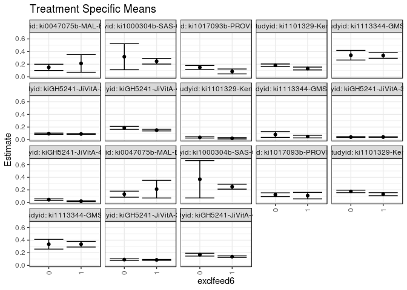

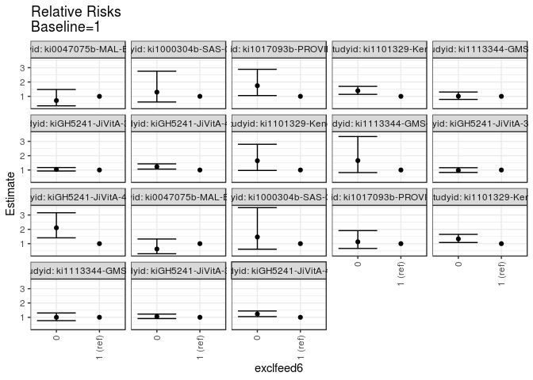

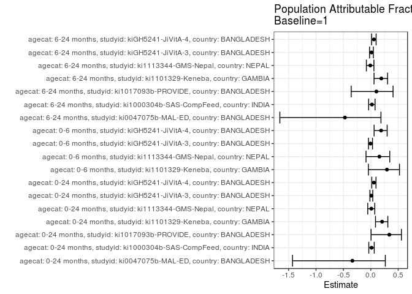

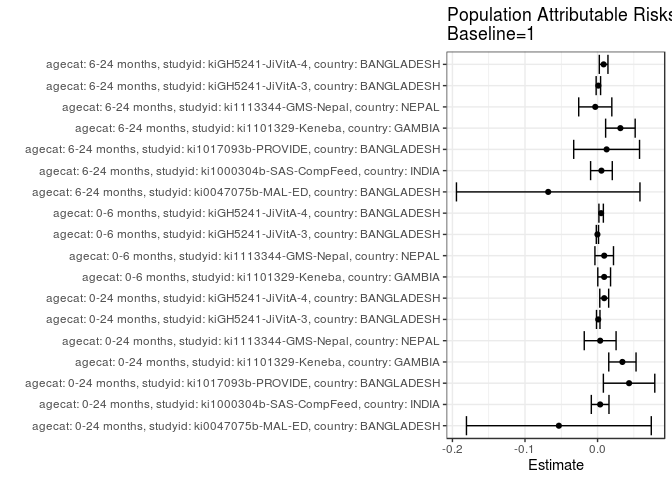

## Results Table

### Parameter: TSM

| agecat | studyid | country | intervention_level | baseline_level | estimate | ci_lower | ci_upper |
| --- | --- | --- | --- | --- | --- | --- | --- |
| 0-24 months | ki0047075b-MAL-ED | BANGLADESH | 1 | NA | 0.2121212 | 0.0723406 | 0.3519018 |
| 0-24 months | ki0047075b-MAL-ED | BANGLADESH | 0 | NA | 0.1500000 | 0.1004068 | 0.1995932 |
| 0-24 months | ki1000304b-SAS-CompFeed | INDIA | 1 | NA | 0.2464455 | 0.2022875 | 0.2906035 |
| 0-24 months | ki1000304b-SAS-CompFeed | INDIA | 0 | NA | 0.3181818 | 0.1124254 | 0.5239382 |
| 0-24 months | ki1017093b-PROVIDE | BANGLADESH | 1 | NA | 0.0851555 | 0.0463152 | 0.1239957 |
| 0-24 months | ki1017093b-PROVIDE | BANGLADESH | 0 | NA | 0.1485808 | 0.1168580 | 0.1803035 |
| 0-24 months | ki1101329-Keneba | GAMBIA | 1 | NA | 0.1317731 | 0.1092677 | 0.1542784 |
| 0-24 months | ki1101329-Keneba | GAMBIA | 0 | NA | 0.1831700 | 0.1633058 | 0.2030341 |
| 0-24 months | ki1113344-GMS-Nepal | NEPAL | 1 | NA | 0.3380131 | 0.2935756 | 0.3824506 |
| 0-24 months | ki1113344-GMS-Nepal | NEPAL | 0 | NA | 0.3419895 | 0.2658495 | 0.4181295 |
| 0-24 months | kiGH5241-JiVitA-3 | BANGLADESH | 1 | NA | 0.0906360 | 0.0852086 | 0.0960633 |
| 0-24 months | kiGH5241-JiVitA-3 | BANGLADESH | 0 | NA | 0.0945767 | 0.0849143 | 0.1042392 |
| 0-24 months | kiGH5241-JiVitA-4 | BANGLADESH | 1 | NA | 0.1517821 | 0.1386771 | 0.1648870 |
| 0-24 months | kiGH5241-JiVitA-4 | BANGLADESH | 0 | NA | 0.1870121 | 0.1634023 | 0.2106219 |
| 0-6 months | ki1101329-Keneba | GAMBIA | 1 | NA | 0.0217680 | 0.0118336 | 0.0317024 |
| 0-6 months | ki1101329-Keneba | GAMBIA | 0 | NA | 0.0358198 | 0.0261325 | 0.0455071 |
| 0-6 months | ki1113344-GMS-Nepal | NEPAL | 1 | NA | 0.0492517 | 0.0284008 | 0.0701026 |
| 0-6 months | ki1113344-GMS-Nepal | NEPAL | 0 | NA | 0.0816092 | 0.0361328 | 0.1270857 |
| 0-6 months | kiGH5241-JiVitA-3 | BANGLADESH | 1 | NA | 0.0419719 | 0.0382119 | 0.0457320 |
| 0-6 months | kiGH5241-JiVitA-3 | BANGLADESH | 0 | NA | 0.0411969 | 0.0350270 | 0.0473669 |
| 0-6 months | kiGH5241-JiVitA-4 | BANGLADESH | 1 | NA | 0.0212322 | 0.0153071 | 0.0271573 |
| 0-6 months | kiGH5241-JiVitA-4 | BANGLADESH | 0 | NA | 0.0447132 | 0.0312724 | 0.0581539 |
| 6-24 months | ki0047075b-MAL-ED | BANGLADESH | 1 | NA | 0.2121212 | 0.0723354 | 0.3519071 |
| 6-24 months | ki0047075b-MAL-ED | BANGLADESH | 0 | NA | 0.1326531 | 0.0850620 | 0.1802441 |
| 6-24 months | ki1000304b-SAS-CompFeed | INDIA | 1 | NA | 0.2512563 | 0.2120897 | 0.2904228 |
| 6-24 months | ki1000304b-SAS-CompFeed | INDIA | 0 | NA | 0.3684211 | 0.0727072 | 0.6641349 |
| 6-24 months | ki1017093b-PROVIDE | BANGLADESH | 1 | NA | 0.1096802 | 0.0581561 | 0.1612043 |
| 6-24 months | ki1017093b-PROVIDE | BANGLADESH | 0 | NA | 0.1235636 | 0.0935666 | 0.1535606 |
| 6-24 months | ki1101329-Keneba | GAMBIA | 1 | NA | 0.1321761 | 0.1080565 | 0.1562957 |
| 6-24 months | ki1101329-Keneba | GAMBIA | 0 | NA | 0.1762787 | 0.1563099 | 0.1962476 |
| 6-24 months | ki1113344-GMS-Nepal | NEPAL | 1 | NA | 0.3353010 | 0.2904522 | 0.3801498 |
| 6-24 months | ki1113344-GMS-Nepal | NEPAL | 0 | NA | 0.3351858 | 0.2579643 | 0.4124073 |
| 6-24 months | kiGH5241-JiVitA-3 | BANGLADESH | 1 | NA | 0.0871046 | 0.0804658 | 0.0937434 |
| 6-24 months | kiGH5241-JiVitA-3 | BANGLADESH | 0 | NA | 0.0919939 | 0.0796973 | 0.1042904 |
| 6-24 months | kiGH5241-JiVitA-4 | BANGLADESH | 1 | NA | 0.1384424 | 0.1261130 | 0.1507719 |
| 6-24 months | kiGH5241-JiVitA-4 | BANGLADESH | 0 | NA | 0.1702165 | 0.1477438 | 0.1926893 |

### Parameter: E(Y)

| agecat | studyid | country | intervention_level | baseline_level | estimate | ci_lower | ci_upper |
| --- | --- | --- | --- | --- | --- | --- | --- |
| 0-24 months | ki0047075b-MAL-ED | BANGLADESH | NA | NA | 0.1587983 | 0.1117681 | 0.2058285 |
| 0-24 months | ki1000304b-SAS-CompFeed | INDIA | NA | NA | 0.2500000 | 0.2118239 | 0.2881761 |
| 0-24 months | ki1017093b-PROVIDE | BANGLADESH | NA | NA | 0.1285714 | 0.1037574 | 0.1533855 |
| 0-24 months | ki1101329-Keneba | GAMBIA | NA | NA | 0.1659955 | 0.1505665 | 0.1814246 |
| 0-24 months | ki1113344-GMS-Nepal | NEPAL | NA | NA | 0.3415929 | 0.3024539 | 0.3807320 |
| 0-24 months | kiGH5241-JiVitA-3 | BANGLADESH | NA | NA | 0.0915608 | 0.0867079 | 0.0964137 |
| 0-24 months | kiGH5241-JiVitA-4 | BANGLADESH | NA | NA | 0.1609510 | 0.1491579 | 0.1727440 |
| 0-6 months | ki1101329-Keneba | GAMBIA | NA | NA | 0.0308725 | 0.0236998 | 0.0380452 |
| 0-6 months | ki1113344-GMS-Nepal | NEPAL | NA | NA | 0.0584071 | 0.0390530 | 0.0777612 |
| 0-6 months | kiGH5241-JiVitA-3 | BANGLADESH | NA | NA | 0.0417690 | 0.0384207 | 0.0451174 |
| 0-6 months | kiGH5241-JiVitA-4 | BANGLADESH | NA | NA | 0.0261535 | 0.0207066 | 0.0316005 |
| 6-24 months | ki0047075b-MAL-ED | BANGLADESH | NA | NA | 0.1441048 | 0.0985189 | 0.1896907 |
| 6-24 months | ki1000304b-SAS-CompFeed | INDIA | NA | NA | 0.2565947 | 0.2209578 | 0.2922316 |
| 6-24 months | ki1017093b-PROVIDE | BANGLADESH | NA | NA | 0.1221498 | 0.0962275 | 0.1480722 |
| 6-24 months | ki1101329-Keneba | GAMBIA | NA | NA | 0.1636364 | 0.1477722 | 0.1795005 |
| 6-24 months | ki1113344-GMS-Nepal | NEPAL | NA | NA | 0.3321364 | 0.2929882 | 0.3712847 |
| 6-24 months | kiGH5241-JiVitA-3 | BANGLADESH | NA | NA | 0.0882064 | 0.0821266 | 0.0942862 |
| 6-24 months | kiGH5241-JiVitA-4 | BANGLADESH | NA | NA | 0.1468045 | 0.1358635 | 0.1577455 |

### Parameter: RR

| agecat | studyid | country | intervention_level | baseline_level | estimate | ci_lower | ci_upper |
| --- | --- | --- | --- | --- | --- | --- | --- |
| 0-24 months | ki0047075b-MAL-ED | BANGLADESH | 1 | 1 | 1.0000000 | 1.0000000 | 1.000000 |
| 0-24 months | ki0047075b-MAL-ED | BANGLADESH | 0 | 1 | 0.7071429 | 0.3383148 | 1.478064 |
| 0-24 months | ki1000304b-SAS-CompFeed | INDIA | 1 | 1 | 1.0000000 | 1.0000000 | 1.000000 |
| 0-24 months | ki1000304b-SAS-CompFeed | INDIA | 0 | 1 | 1.2910839 | 0.6050646 | 2.754908 |
| 0-24 months | ki1017093b-PROVIDE | BANGLADESH | 1 | 1 | 1.0000000 | 1.0000000 | 1.000000 |
| 0-24 months | ki1017093b-PROVIDE | BANGLADESH | 0 | 1 | 1.7448181 | 1.0541333 | 2.888050 |
| 0-24 months | ki1101329-Keneba | GAMBIA | 1 | 1 | 1.0000000 | 1.0000000 | 1.000000 |
| 0-24 months | ki1101329-Keneba | GAMBIA | 0 | 1 | 1.3900409 | 1.1392766 | 1.696001 |
| 0-24 months | ki1113344-GMS-Nepal | NEPAL | 1 | 1 | 1.0000000 | 1.0000000 | 1.000000 |
| 0-24 months | ki1113344-GMS-Nepal | NEPAL | 0 | 1 | 1.0117641 | 0.7860047 | 1.302367 |
| 0-24 months | kiGH5241-JiVitA-3 | BANGLADESH | 1 | 1 | 1.0000000 | 1.0000000 | 1.000000 |
| 0-24 months | kiGH5241-JiVitA-3 | BANGLADESH | 0 | 1 | 1.0434790 | 0.9301057 | 1.170672 |
| 0-24 months | kiGH5241-JiVitA-4 | BANGLADESH | 1 | 1 | 1.0000000 | 1.0000000 | 1.000000 |
| 0-24 months | kiGH5241-JiVitA-4 | BANGLADESH | 0 | 1 | 1.2321090 | 1.0623331 | 1.429018 |
| 0-6 months | ki1101329-Keneba | GAMBIA | 1 | 1 | 1.0000000 | 1.0000000 | 1.000000 |
| 0-6 months | ki1101329-Keneba | GAMBIA | 0 | 1 | 1.6455229 | 0.9681304 | 2.796881 |
| 0-6 months | ki1113344-GMS-Nepal | NEPAL | 1 | 1 | 1.0000000 | 1.0000000 | 1.000000 |
| 0-6 months | ki1113344-GMS-Nepal | NEPAL | 0 | 1 | 1.6569838 | 0.8224800 | 3.338191 |
| 0-6 months | kiGH5241-JiVitA-3 | BANGLADESH | 1 | 1 | 1.0000000 | 1.0000000 | 1.000000 |
| 0-6 months | kiGH5241-JiVitA-3 | BANGLADESH | 0 | 1 | 0.9815350 | 0.8307666 | 1.159665 |
| 0-6 months | kiGH5241-JiVitA-4 | BANGLADESH | 1 | 1 | 1.0000000 | 1.0000000 | 1.000000 |
| 0-6 months | kiGH5241-JiVitA-4 | BANGLADESH | 0 | 1 | 2.1059164 | 1.4048841 | 3.156761 |
| 6-24 months | ki0047075b-MAL-ED | BANGLADESH | 1 | 1 | 1.0000000 | 1.0000000 | 1.000000 |
| 6-24 months | ki0047075b-MAL-ED | BANGLADESH | 0 | 1 | 0.6253644 | 0.2953068 | 1.324320 |
| 6-24 months | ki1000304b-SAS-CompFeed | INDIA | 1 | 1 | 1.0000000 | 1.0000000 | 1.000000 |
| 6-24 months | ki1000304b-SAS-CompFeed | INDIA | 0 | 1 | 1.4663158 | 0.6118309 | 3.514177 |
| 6-24 months | ki1017093b-PROVIDE | BANGLADESH | 1 | 1 | 1.0000000 | 1.0000000 | 1.000000 |
| 6-24 months | ki1017093b-PROVIDE | BANGLADESH | 0 | 1 | 1.1265805 | 0.6640835 | 1.911181 |
| 6-24 months | ki1101329-Keneba | GAMBIA | 1 | 1 | 1.0000000 | 1.0000000 | 1.000000 |
| 6-24 months | ki1101329-Keneba | GAMBIA | 0 | 1 | 1.3336655 | 1.0790008 | 1.648436 |
| 6-24 months | ki1113344-GMS-Nepal | NEPAL | 1 | 1 | 1.0000000 | 1.0000000 | 1.000000 |
| 6-24 months | ki1113344-GMS-Nepal | NEPAL | 0 | 1 | 0.9996564 | 0.7673746 | 1.302249 |
| 6-24 months | kiGH5241-JiVitA-3 | BANGLADESH | 1 | 1 | 1.0000000 | 1.0000000 | 1.000000 |
| 6-24 months | kiGH5241-JiVitA-3 | BANGLADESH | 0 | 1 | 1.0561307 | 0.9115876 | 1.223593 |
| 6-24 months | kiGH5241-JiVitA-4 | BANGLADESH | 1 | 1 | 1.0000000 | 1.0000000 | 1.000000 |
| 6-24 months | kiGH5241-JiVitA-4 | BANGLADESH | 0 | 1 | 1.2295112 | 1.0497253 | 1.440089 |

### Parameter: PAR

| agecat | studyid | country | intervention_level | baseline_level | estimate | ci_lower | ci_upper |
| --- | --- | --- | --- | --- | --- | --- | --- |
| 0-24 months | ki0047075b-MAL-ED | BANGLADESH | 1 | NA | -0.0533229 | -0.1806646 | 0.0740188 |
| 0-24 months | ki1000304b-SAS-CompFeed | INDIA | 1 | NA | 0.0035545 | -0.0086130 | 0.0157220 |
| 0-24 months | ki1017093b-PROVIDE | BANGLADESH | 1 | NA | 0.0434160 | 0.0079961 | 0.0788359 |
| 0-24 months | ki1101329-Keneba | GAMBIA | 1 | NA | 0.0342225 | 0.0154225 | 0.0530225 |
| 0-24 months | ki1113344-GMS-Nepal | NEPAL | 1 | NA | 0.0035798 | -0.0183511 | 0.0255107 |
| 0-24 months | kiGH5241-JiVitA-3 | BANGLADESH | 1 | NA | 0.0009248 | -0.0014610 | 0.0033107 |
| 0-24 months | kiGH5241-JiVitA-4 | BANGLADESH | 1 | NA | 0.0091689 | 0.0030407 | 0.0152971 |
| 0-6 months | ki1101329-Keneba | GAMBIA | 1 | NA | 0.0091045 | 0.0003140 | 0.0178949 |
| 0-6 months | ki1113344-GMS-Nepal | NEPAL | 1 | NA | 0.0091554 | -0.0036364 | 0.0219472 |
| 0-6 months | kiGH5241-JiVitA-3 | BANGLADESH | 1 | NA | -0.0002029 | -0.0017370 | 0.0013312 |
| 0-6 months | kiGH5241-JiVitA-4 | BANGLADESH | 1 | NA | 0.0049213 | 0.0018648 | 0.0079779 |
| 6-24 months | ki0047075b-MAL-ED | BANGLADESH | 1 | NA | -0.0680164 | -0.1944542 | 0.0584214 |
| 6-24 months | ki1000304b-SAS-CompFeed | INDIA | 1 | NA | 0.0053384 | -0.0095993 | 0.0202761 |
| 6-24 months | ki1017093b-PROVIDE | BANGLADESH | 1 | NA | 0.0124696 | -0.0328902 | 0.0578295 |
| 6-24 months | ki1101329-Keneba | GAMBIA | 1 | NA | 0.0314602 | 0.0111081 | 0.0518124 |
| 6-24 months | ki1113344-GMS-Nepal | NEPAL | 1 | NA | -0.0031646 | -0.0259744 | 0.0196452 |
| 6-24 months | kiGH5241-JiVitA-3 | BANGLADESH | 1 | NA | 0.0011018 | -0.0019629 | 0.0041665 |
| 6-24 months | kiGH5241-JiVitA-4 | BANGLADESH | 1 | NA | 0.0083620 | 0.0024110 | 0.0143131 |

### Parameter: PAF

| agecat | studyid | country | intervention_level | baseline_level | estimate | ci_lower | ci_upper |
| --- | --- | --- | --- | --- | --- | --- | --- |
| 0-24 months | ki0047075b-MAL-ED | BANGLADESH | 1 | NA | -0.3357903 | -1.4291848 | 0.2654590 |
| 0-24 months | ki1000304b-SAS-CompFeed | INDIA | 1 | NA | 0.0142180 | -0.0365627 | 0.0625110 |
| 0-24 months | ki1017093b-PROVIDE | BANGLADESH | 1 | NA | 0.3376798 | 0.0047524 | 0.5592373 |
| 0-24 months | ki1101329-Keneba | GAMBIA | 1 | NA | 0.2061650 | 0.0858063 | 0.3106778 |
| 0-24 months | ki1113344-GMS-Nepal | NEPAL | 1 | NA | 0.0104798 | -0.0558342 | 0.0726287 |
| 0-24 months | kiGH5241-JiVitA-3 | BANGLADESH | 1 | NA | 0.0101008 | -0.0163135 | 0.0358286 |
| 0-24 months | kiGH5241-JiVitA-4 | BANGLADESH | 1 | NA | 0.0569670 | 0.0180217 | 0.0943677 |
| 0-6 months | ki1101329-Keneba | GAMBIA | 1 | NA | 0.2949056 | -0.0437161 | 0.5236653 |
| 0-6 months | ki1113344-GMS-Nepal | NEPAL | 1 | NA | 0.1567516 | -0.0871969 | 0.3459622 |
| 0-6 months | kiGH5241-JiVitA-3 | BANGLADESH | 1 | NA | -0.0048576 | -0.0422445 | 0.0311881 |
| 0-6 months | kiGH5241-JiVitA-4 | BANGLADESH | 1 | NA | 0.1881716 | 0.0602066 | 0.2987124 |
| 6-24 months | ki0047075b-MAL-ED | BANGLADESH | 1 | NA | -0.4719927 | -1.6599630 | 0.1854164 |
| 6-24 months | ki1000304b-SAS-CompFeed | INDIA | 1 | NA | 0.0208050 | -0.0393691 | 0.0774953 |
| 6-24 months | ki1017093b-PROVIDE | BANGLADESH | 1 | NA | 0.1020848 | -0.3577406 | 0.4061814 |
| 6-24 months | ki1101329-Keneba | GAMBIA | 1 | NA | 0.1922570 | 0.0590042 | 0.3066402 |
| 6-24 months | ki1113344-GMS-Nepal | NEPAL | 1 | NA | -0.0095280 | -0.0806314 | 0.0568970 |
| 6-24 months | kiGH5241-JiVitA-3 | BANGLADESH | 1 | NA | 0.0124912 | -0.0228279 | 0.0465908 |
| 6-24 months | kiGH5241-JiVitA-4 | BANGLADESH | 1 | NA | 0.0569604 | 0.0154132 | 0.0967543 |